# Attendance Analysis and Modelling

Steph Oliva and Chris Haid

This is a first pass at modeling student-level attendence. The primary use cases are: * to provide predictions of end-of-year average daily attendance (ADA) by for each student earlier in the year (say the middle of the 1st quarter). * to provide predictions of end-of-year aveage daily attendance (ADA) by for each school and at the school level earlier in the year (say the middle of the 1st quarter). * Prepare for the addition of an On-Track metric in SQRP.

Another goal is gain familiarity with the tidymodels suite of packages (e.g, `recipes`, `parsnip`, `resample`)

```r
library(tidyverse)
library(silounloadr)
library(kippcolors)
library(janitor)
library(lubridate)
library(caret)
library(broom)
library(modelr)
library(tidymodels)
theme_set(theme_kipp_light())


bigrquery::set_service_token("kipp-chicago-silo-2-aa786970aefd.json")
```

```r
knitr::opts_knit$set(comment = FALSE,
                     warning = FALSE,
                     progress = FALSE,
                     verbose = FALSE)

knitr::opts_chunk$set(fig.width = 10)
```

Here we grab basic attendances and enrollment data from Silo (our warehouse):

```r
membership <- get_powerschool("ps_membership_reg") %>%
  select(studentid,
         schoolid,
         date = calendardate,
         enrolled = studentmembership,
         grade_level,
         attendance = ATT_CalcCntPresentAbsent,
         yearid) %>%
  filter(yearid >= 25)


attendance <- get_powerschool("attendance") %>%
  filter(yearid >= 25,
        att_mode_code == "ATT_ModeDaily")

attendance_code <- get_powerschool("attendance_code") %>%
  mutate(att_code = if_else(att_code == "true", "T", att_code)) %>%
  select(attendance_codeid = id,
         att_code)
```

And now we do some pre-procecessing:

```r
member_att <- membership %>%
  dplyr::left_join(attendance %>%
              select(-schoolid,
                        -yearid) %>%
              dplyr::left_join(attendance_code,
                        by = "attendance_codeid"),
            by = c("studentid",
                   "date" = "att_date")) %>%
  collect()
```

Recoding enrollmeent and attendance data:

```r
member_att %>%
  janitor::tabyl(att_code)
```

| att_code | n | percent | valid_percent |
| --- | --- | --- | --- |
| A | 48873 | 3.669808e-02 | 1.595791e-01 |
| D | 4103 | 3.080888e-03 | 1.339703e-02 |
| E | 5186 | 3.894098e-03 | 1.693321e-02 |
| H | 2839 | 2.131767e-03 | 9.269841e-03 |
| I | 53 | 3.979699e-05 | 1.730544e-04 |
| P | 2 | 1.501773e-06 | 6.530356e-06 |
| S | 1562 | 1.172885e-03 | 5.100208e-03 |
| T | 243644 | 1.829490e-01 | 7.955411e-01 |
| NA | 1025497 | 7.700320e-01 | NA |

```r
student_att <- member_att %>%
  mutate(enrolled0 = 1,
         enrolled = if_else(att_code == "D" & !is.na(att_code), 0, enrolled0),
         present0 = ifelse(is.na(att_code), 1, 0),
         present1 = ifelse(att_code %in%  c("A", "S"), 0, present0),
         present2 = ifelse(att_code == "H", 0.5, present1),
         present3 = ifelse(att_code %in% c("T", "E", "I"), 1, present2),
         present = ifelse(is.na(present2), 1, present3),
         absent = (1 - present)*enrolled,
         tardy = ifelse(att_code %in% "T", 1, 0),
         dna0 = if_else(att_code == "D", 1, 0),
         dna = if_else(is.na(dna0), 0, dna0)) %>%
  select(yearid,
         schoolid,
         studentid,
         grade_level,
         date,
         att_code,
         enrolled,
         present,
         absent,
         tardy,
         dna)
```

Now we calculate some quantitities of interest: year_end ADA, cumulative ADA by date

```r
yearly_ada <- student_att %>%
  filter(yearid < 28) %>%
  group_by(yearid,
           studentid) %>%
  summarize(enrolled = sum(enrolled),
            absent = sum(absent),
            year_end = 1 - (absent/enrolled))

cum_ada <- student_att %>%
  filter(yearid < 28) %>%
  group_by(yearid,
           studentid) %>%
  arrange(date) %>%
  mutate(cum_enrolled = cumsum(enrolled),
         cum_absent = cumsum(absent),
         running_ada = 1 - (cum_absent/cum_enrolled)) %>%
  filter(cum_enrolled > 0)

yearly_cum_ada <- cum_ada %>%
  select(yearid,
         schoolid,
         grade_level,
         studentid,
         date,
         cum_enrolled,
         cum_absent,
         running_ada) %>%
  dplyr::left_join(yearly_ada %>%
              select(-c(enrolled,
                        absent)),
            by = c("yearid",
                   "studentid"))

yearly_cum_ada %>% filter(studentid == 14852)
```

| yearid | schoolid | grade_level | studentid | date | cum_enrolled | cum_absent | running_ada | year_end |
| --- | --- | --- | --- | --- | --- | --- | --- | --- |
| 25 | 78102 | 0 | 14852 | 2015-08-19 | 1 | 1.0 | 0.0000000 | 0.8823529 |
| 25 | 78102 | 0 | 14852 | 2015-08-20 | 2 | 2.0 | 0.0000000 | 0.8823529 |
| 25 | 78102 | 0 | 14852 | 2015-08-21 | 3 | 2.0 | 0.3333333 | 0.8823529 |
| 25 | 78102 | 0 | 14852 | 2015-08-24 | 4 | 3.0 | 0.2500000 | 0.8823529 |
| 25 | 78102 | 0 | 14852 | 2015-08-25 | 5 | 4.0 | 0.2000000 | 0.8823529 |
| 25 | 78102 | 0 | 14852 | 2015-08-26 | 6 | 4.0 | 0.3333333 | 0.8823529 |
| 25 | 78102 | 0 | 14852 | 2015-08-27 | 7 | 5.0 | 0.2857143 | 0.8823529 |
| 25 | 78102 | 0 | 14852 | 2015-08-28 | 8 | 5.0 | 0.3750000 | 0.8823529 |
| 25 | 78102 | 0 | 14852 | 2015-08-31 | 9 | 5.0 | 0.4444444 | 0.8823529 |
| 25 | 78102 | 0 | 14852 | 2015-09-01 | 10 | 5.0 | 0.5000000 | 0.8823529 |

[output cut: 534 more lines]

Now we begin doing some subsetting to build a basic model. We’ll pull the data for each student over the last few years (excluding SY 18-19) for the last school day in December. We’ll build our model off of this “snapshot”. The resulting table shows for each student their number of days enrolled (`cum_enrolled`), days absent (`cum_absent`), ADA through last school day in december (`running_ada`), and the given year’s EOY ADA (`year_end`).

```r
dec_dates <- yearly_cum_ada %>%
  group_by(yearid) %>%
  select(date) %>%
  distinct() %>%
  filter(lubridate::month(date) == 12) %>%
  filter(date == max(date))
yca_filtered <- yearly_cum_ada %>%
  inner_join(dec_dates %>%
               ungroup() %>%
               select(-yearid),
             by = c("date")) %>%
  ungroup() %>%
  mutate(yearid = as.factor(yearid))


yca_filtered
```

| yearid | schoolid | grade_level | studentid | date | cum_enrolled | cum_absent | running_ada | year_end |
| --- | --- | --- | --- | --- | --- | --- | --- | --- |
| 25 | 78102 | 0 | 14877 | 2015-12-18 | 80 | 12.0 | 0.8500000 | 0.7807487 |
| 25 | 78102 | 0 | 15031 | 2015-12-18 | 73 | 6.0 | 0.9178082 | 0.9388889 |
| 25 | 78102 | 0 | 14905 | 2015-12-18 | 80 | 7.0 | 0.9125000 | 0.9197861 |
| 25 | 78102 | 0 | 14829 | 2015-12-18 | 80 | 11.0 | 0.8625000 | 0.8716578 |
| 25 | 78102 | 0 | 14885 | 2015-12-18 | 80 | 1.0 | 0.9875000 | 0.9786096 |
| 25 | 78102 | 0 | 14840 | 2015-12-18 | 80 | 14.0 | 0.8250000 | 0.8556150 |
| 25 | 78102 | 0 | 14868 | 2015-12-18 | 80 | 3.0 | 0.9625000 | 0.9518717 |
| 25 | 78102 | 0 | 14879 | 2015-12-18 | 80 | 10.0 | 0.8750000 | 0.8877005 |
| 25 | 400146 | 5 | 15172 | 2015-12-18 | 77 | 16.0 | 0.7922078 | 0.7708333 |
| 25 | 7810 | 6 | 15280 | 2015-12-18 | 60 | 8.0 | 0.8666667 | 0.8090909 |

[output cut: 4981 more lines]

## Models

our first model (`mod_0`) models year end ADA as a function of cumulative days enrolled and cumulaitve days absent through the last day of December, using school year as a fixed effect:

$$y_{i} = f(\alpha + \beta_{e}d_{e} + \beta_{a}d_{a} +\delta_{year} )$$

We’ll first fit a linear model:

```r
formula_0 <- as.formula(year_end ~ cum_enrolled + cum_absent + yearid)

mod_0 <- lm(formula = formula_0,
            data = yca_filtered)

summary(mod_0)
```

```
##
## Call:
## lm(formula = formula_0, data = yca_filtered)
##
## Residuals:
##       Min        1Q    Median        3Q       Max
## -0.199491 -0.008197  0.004754  0.012723  0.142905
##
## Coefficients:
##                Estimate Std. Error  t value Pr(>|t|)
## (Intercept)   9.139e-01  4.391e-03  208.139  < 2e-16 ***
## cum_enrolled  8.508e-04  5.482e-05   15.521  < 2e-16 ***
## cum_absent   -1.050e-02  8.611e-05 -121.913  < 2e-16 ***
## yearid26      1.188e-02  9.109e-04   13.044  < 2e-16 ***
## yearid27      6.599e-03  8.793e-04    7.505 7.22e-14 ***
## ---
## Signif. codes:  0 '***' 0.001 '**' 0.01 '*' 0.05 '.' 0.1 ' ' 1
##
## Residual standard error: 0.02485 on 4986 degrees of freedom
## Multiple R-squared:  0.756,  Adjusted R-squared:  0.7558
## F-statistic:  3862 on 4 and 4986 DF,  p-value: < 2.2e-16
```

Let’s plot the ranked residulas of `mod_0`)

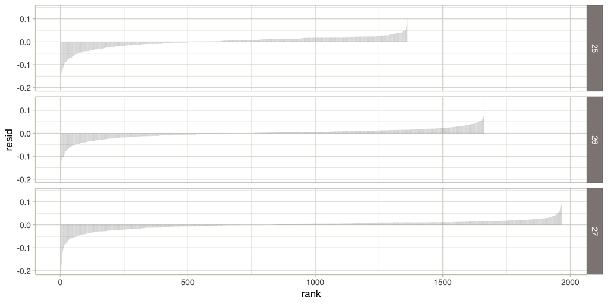

```r
# yca_filtered %>%
#   ungroup() %>%
#   modelr::add_predictions(mod_0) %>%
#   modelr::add_residuals(mod_0) %>%
#   arrange(resid) %>%
#   group_by(yearid) %>%
#   mutate(rank = row_number(resid)) %>%
#   ggplot(aes(x = rank, y = resid)) +
#   geom_segment(aes(xend = rank, yend = 0),
#                size = .075, alph=.3) +
#   facet_grid(yearid~.)


plot_ranked_residuals <- function(data,model){
data %>%
  modelr::add_predictions(model) %>%
  modelr::add_residuals(model) %>%
  arrange(resid) %>%
  group_by(yearid) %>%
  mutate(rank = row_number(resid)) %>%
  ggplot(aes(x = rank, y = resid)) +
  geom_segment(aes(xend = rank, yend = 0),
               size = .075, alpha =  .3) +
  facet_grid(yearid~.)


}

plot_ranked_residuals(yca_filtered, mod_0)
```

And heres the residuals as a funtion of actuals.

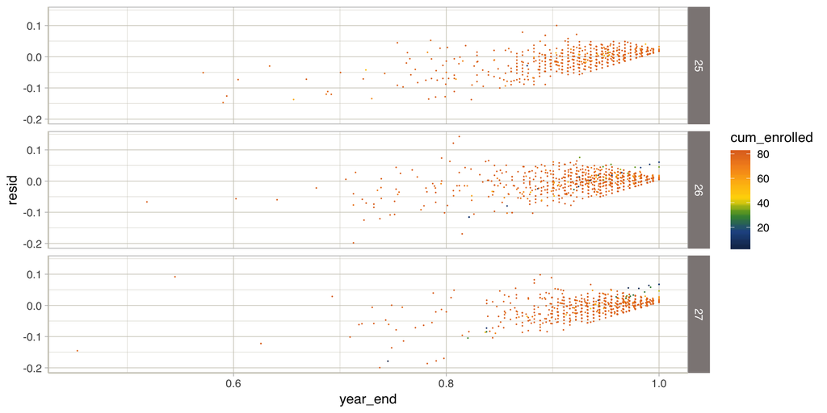

```r
# yca_filtered %>%
#   ungroup() %>%
#   modelr::add_predictions(mod_0) %>%
#   modelr::add_residuals(mod_0) %>%
#   arrange(resid) %>%
#   group_by(yearid) %>%
#   mutate(rank = row_number(resid)) %>%
#   ggplot(aes(x = year_end, y = resid)) +
#   geom_point(aes(color = cum_enrolled),
#              size = .001) +
#   scale_color_kipp(discrete = FALSE) +
#   facet_grid(yearid ~.)

plot_actual_v_residuals <- function(data, model){
  data %>%
  ungroup() %>%
  modelr::add_predictions(model) %>%
  modelr::add_residuals(model) %>%
  arrange(resid) %>%
  group_by(yearid) %>%
  mutate(rank = row_number(resid)) %>%
  ggplot(aes(x = year_end, y = resid)) +
  geom_point(aes(color = cum_enrolled),
             size = .001) +
  scale_color_kipp(discrete = FALSE) +
  facet_grid(yearid ~.)
}


plot_actual_v_residuals(yca_filtered, mod_0)
```

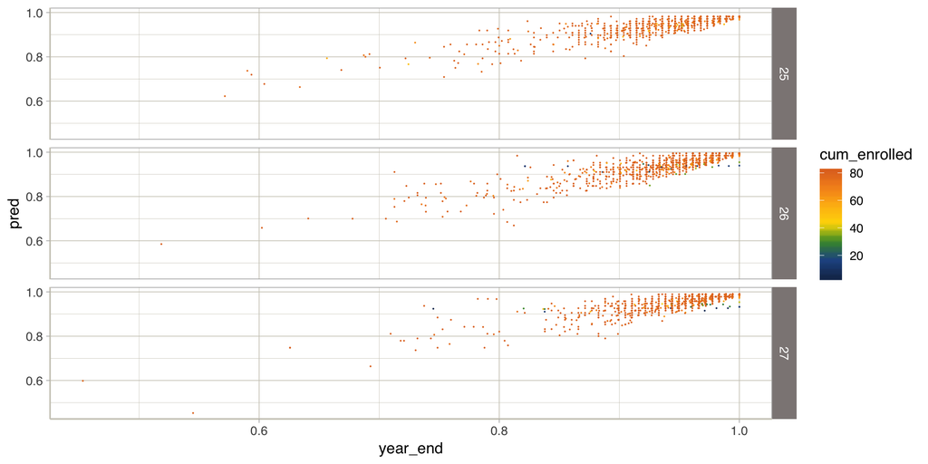

```r
plot_actual_v_predicted <- function(data, model){
  data %>%
  ungroup() %>%
  modelr::add_predictions(model) %>%
  modelr::add_residuals(model) %>%
  arrange(resid) %>%
  group_by(yearid) %>%
  mutate(rank = row_number(resid)) %>%
  ggplot(aes(x = year_end, y = pred)) +
  geom_point(aes(color = cum_enrolled),
             size = .001) +
  scale_color_kipp(discrete = FALSE) +
  facet_grid(yearid ~.)
}

plot_actual_v_predicted(yca_filtered, mod_0)
```

Let’s fits these with a logit

```r
mod_1 <- glm(formula = formula_0,
             family = binomial(link = "logit"),
             data = yca_filtered)
summary(mod_1)
```

```
##
## Call:
## glm(formula = formula_0, family = binomial(link = "logit"), data = yca_filtered)
##
## Deviance Residuals:
##      Min        1Q    Median        3Q       Max
## -0.74372  -0.05527   0.02874   0.11069   1.36702
##
## Coefficients:
##               Estimate Std. Error z value Pr(>|z|)
## (Intercept)   2.109887   0.689484   3.060  0.00221 **
## cum_enrolled  0.017037   0.008641   1.972  0.04866 *
## cum_absent   -0.129034   0.010785 -11.964  < 2e-16 ***
## yearid26      0.227414   0.170340   1.335  0.18186
## yearid27      0.229005   0.173188   1.322  0.18607
## ---
## Signif. codes:  0 '***' 0.001 '**' 0.01 '*' 0.05 '.' 0.1 ' ' 1
##
## (Dispersion parameter for binomial family taken to be 1)
##
##     Null deviance: 229.328  on 4990  degrees of freedom
## Residual deviance:  93.431  on 4986  degrees of freedom
## AIC: 502.16
##
## Number of Fisher Scoring iterations: 6
```

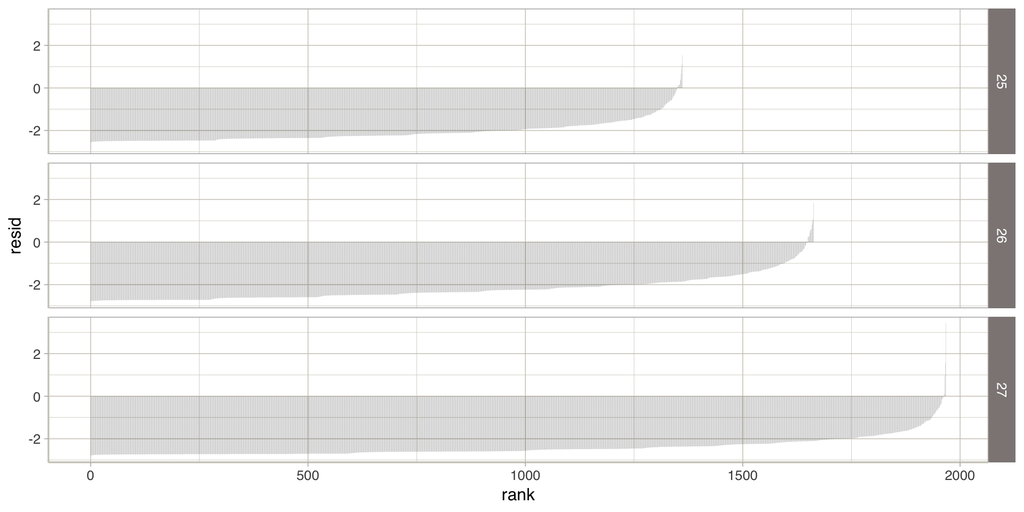

```r
plot_ranked_residuals(yca_filtered, mod_1)
```

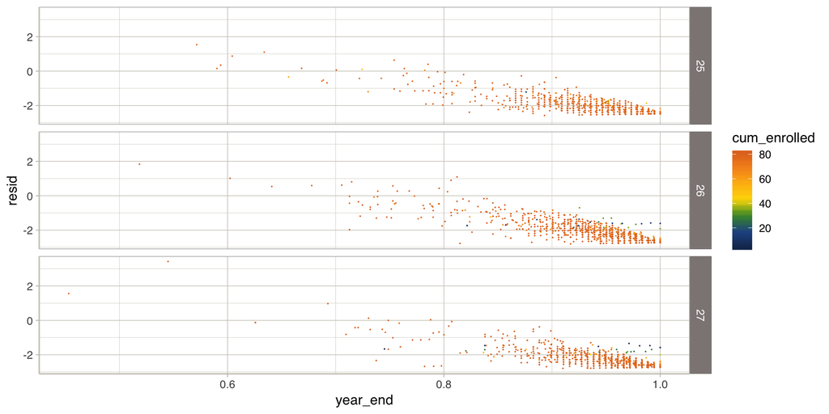

```r
plot_actual_v_residuals(yca_filtered, mod_1)
```

```r
yca_filtered %>%
  ungroup() %>%
  modelr::add_predictions(mod_1) %>%
  modelr::add_residuals(mod_1)
```

| yearid | schoolid | grade_level | studentid | date | cum_enrolled | cum_absent | running_ada | year_end | pred | resid |
| --- | --- | --- | --- | --- | --- | --- | --- | --- | --- | --- |
| 25 | 78102 | 0 | 14877 | 2015-12-18 | 80 | 12.0 | 0.8500000 | 0.7807487 | 1.92447955 | -1.143730887 |
| 25 | 78102 | 0 | 15031 | 2015-12-18 | 73 | 6.0 | 0.9178082 | 0.9388889 | 2.57941977 | -1.640530881 |
| 25 | 78102 | 0 | 14905 | 2015-12-18 | 80 | 7.0 | 0.9125000 | 0.9197861 | 2.56964830 | -1.649862207 |
| 25 | 78102 | 0 | 14829 | 2015-12-18 | 80 | 11.0 | 0.8625000 | 0.8716578 | 2.05351330 | -1.181855547 |
| 25 | 78102 | 0 | 14885 | 2015-12-18 | 80 | 1.0 | 0.9875000 | 0.9786096 | 3.34385081 | -2.365241181 |
| 25 | 78102 | 0 | 14840 | 2015-12-18 | 80 | 14.0 | 0.8250000 | 0.8556150 | 1.66641205 | -0.810797076 |
| 25 | 78102 | 0 | 14868 | 2015-12-18 | 80 | 3.0 | 0.9625000 | 0.9518717 | 3.08578331 | -2.133911648 |
| 25 | 78102 | 0 | 14879 | 2015-12-18 | 80 | 10.0 | 0.8750000 | 0.8877005 | 2.18254705 | -1.294846517 |
| 25 | 400146 | 5 | 15172 | 2015-12-18 | 77 | 16.0 | 0.7922078 | 0.7708333 | 1.35723214 | -0.586398807 |
| 25 | 7810 | 6 | 15280 | 2015-12-18 | 60 | 8.0 | 0.8666667 | 0.8090909 | 2.09986517 | -1.290774260 |

[output cut: 4981 more lines]

## Partitioning

WE need to partition in train and test to better evaluate our models.

We’ll take rsample for a spin!

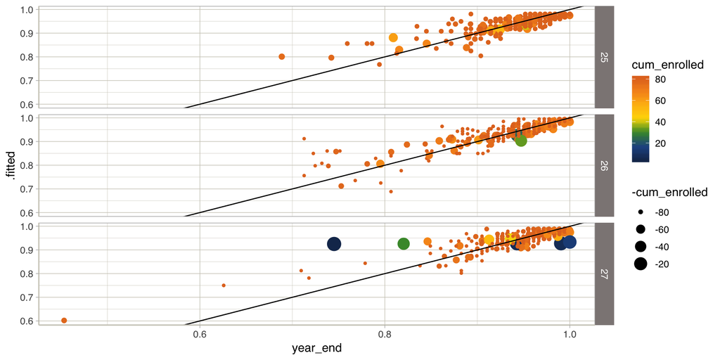

```r
yca_split <- yca_filtered %>%
  rsample::initial_split(prop = .75)

yca_train <- analysis(yca_split)
yca_test <- assessment(yca_split)


mod_lm_train <- lm(formula = formula_0, data = yca_train)

yca_augmented <- broom::augment(mod_lm_train,
                                newdata = yca_test) %>%
  mutate(resid = year_end - .fitted)

yca_augmented %>%
  ggplot(aes(x = year_end, y = .fitted)) +
  geom_point(aes(color = cum_enrolled, size = -cum_enrolled)) +
  geom_abline(aes(intercept = 0, slope = 1)) +
  facet_grid(yearid~.) +
  scale_color_kipp(discrete = FALSE)
```

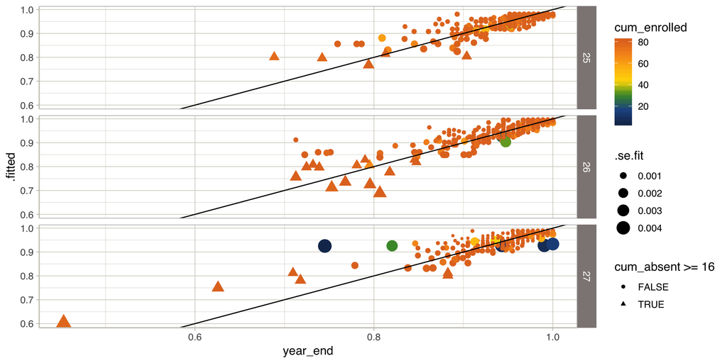

```r
yca_augmented %>%
  ggplot(aes(x = year_end, y = .fitted)) +
  geom_point(aes(color = cum_enrolled, size = .se.fit, shape = cum_absent>=16)) +
  geom_abline(aes(intercept = 0, slope = 1)) +
  facet_grid(yearid~.) +
  scale_color_kipp(discrete = FALSE)
```

To do: we should distance to school.